# index.Rmd

Daniella Tsing, Brandon Nguyen, Eugene Kim, Roberto Raftery

2022-05-12

### **Introduction**

The data set contains information about the indicators of diabetes for 253,680 survey respondents. Indicators include factors such as cholesterol levels, BMI, and income. The data was collected by the Centers for Disease Control and Prevention (CDC) via a telephone survey called the Behavioral Risk Factor Surveillance System (BRFSS) in 2015. The data set contains 22 columns and 253,680 rows. From this dataset, we are able to determine factors that influence an individual’s likelihood of becoming diagnosed with diabetes. These factors include social and behavioral factors along with health factors, so we will also be able to analyze the intersection between an individual’s social environment and an individual’s physical well-being. The social factors provided in this dataset include age, income, and sex. From these categories, we may discern whether men or women are more likely to become diabetics, how income factors into healthcare, and what age group has the highest number of diabetics. By analyzing social factors, we can ask further questions to explore the cause and effect relationships created by these factors. Moreover, the dataset contains information about an individual’s behavioral, such as smoking and eating habits, and how it predisposes them to diabetes. Along with health factors such as cholesterol levels, these social and behavioral patterns will give us a more well-rounded understanding of the contributors to diabetes.

### **Summary**

31.9440106, 0.2428906, 0.0796039, 10, 0.2868065

### **Charts**

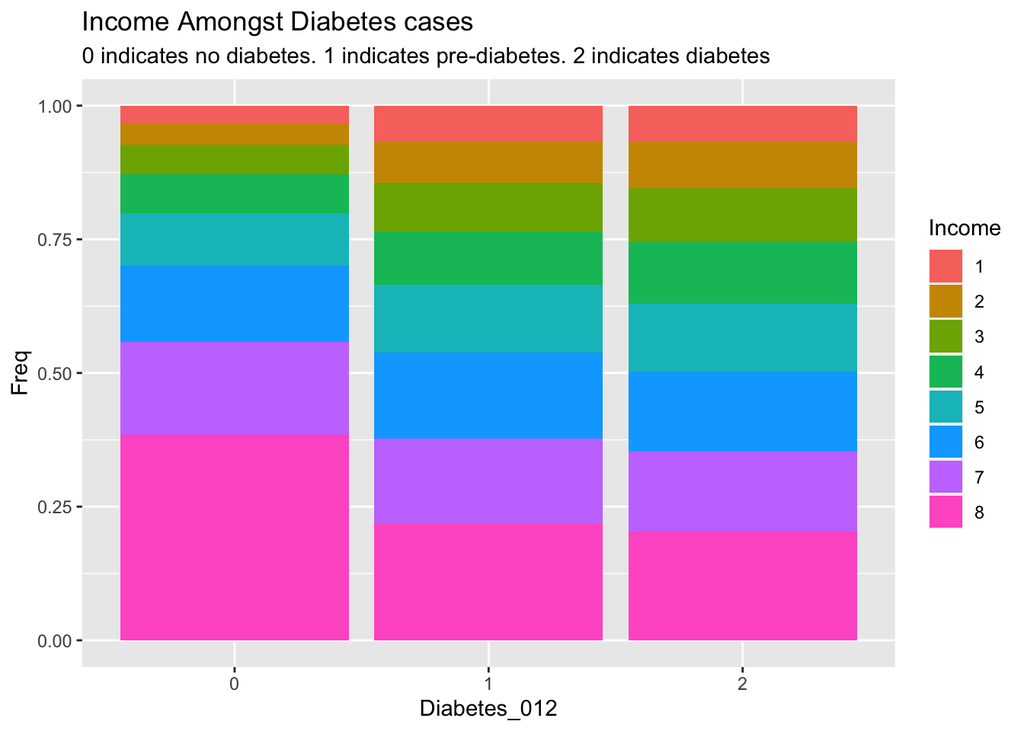

The purpose of this chart allows us to see a comparison of the different levels of income, and how they relate to diabetes. With 1 being the lowest and 8 being the highest, we can notice some trends between people without diabetes (0), pre-diabetes (1), and people with diabetes(2). As we go from 0 to 2 on the x-axis, we can see how the income ranges shift upward in frequency. This is indicative of a trend that displays how incomes correlates with diabetes. We can also see it as an inversely proportional relationship as we can see that people without diabetes tend to have more in higher income

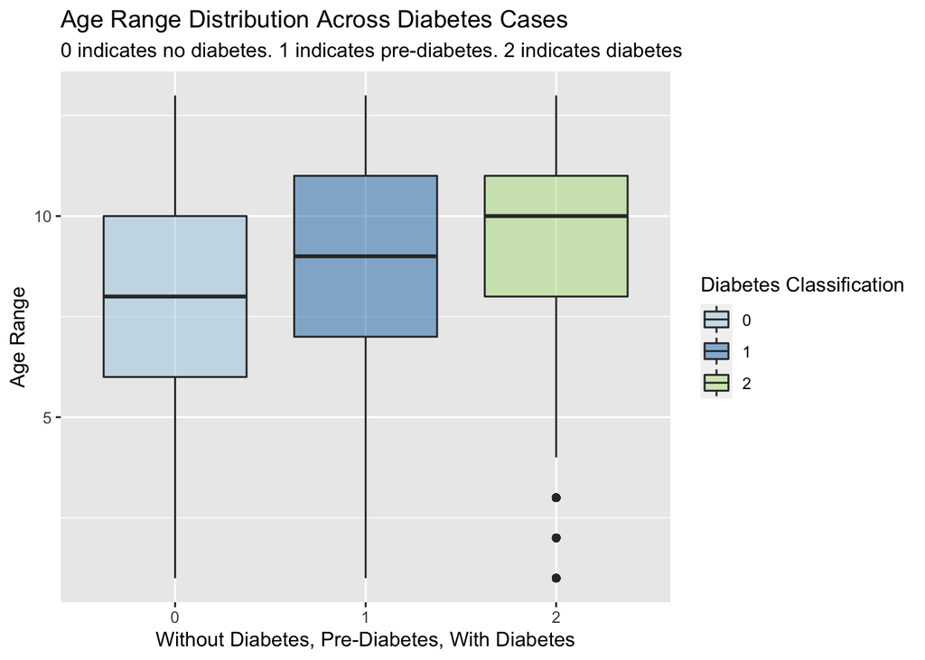

This chart examines the age distribution among the diabetes classification. Age ranges are given values ranging from 1 to 13. Age-group 1 includes ages 18-24, and past this group, the age ranges increase in increments of 4 with age-group 13 including ages 80 or older (An easy way to calculate this can be to understand that age ranges are in increments of 4, so the starting age of any given age range can be found by 15 + 5*age_group, eg. age_group 5 is the age range between 15 + 5x5 = 40 which is the starting age, and the range ranges by 4 years so the resulting age range is 40-44). We can identify trends in the age ranges in the max, min, and interquartile ranges of the box plot. Among all classifications of diabetes, the youngest age is in age-group 1 and the highest age is in age-group 13. However, we can see a shift in age range of the interquartile range with each classification as the range shifts upwards.

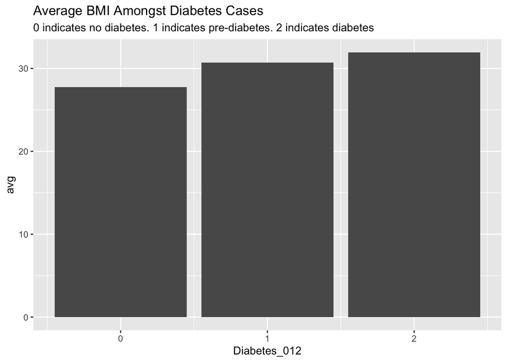